# Dimension Reduction

TU059 - Phase 2 Task 4 - Dimension Reducton

Author

Student Number: D24127620, Student Name: Eamonn Kelly, Programme Code: TU059

# Introduction

Complete the PCA making relevant decisions and report your findings. https://www.kaggle.com/datasets/hayriyigit/website-satisfaction-survey

These are the variables of interest to this task:

*Navigation:*

| **Variable** | **Meaning** |
| --- | --- |
| **q1** | Ease of navigating the website |
| **q2** | Clarity of the menu/structure |
| **q3** | Ease of finding information |
| **q4** | Website is intuitive to use |
| **q5** | Layout helps navigation |

*Typography:*

| **Variable** | **Meaning** |
| --- | --- |
| **q9** | Text readability and formatting |

*Colour:*

| **Variable** | **Meaning** |
| --- | --- |
| **q7** | Colour scheme suitability |
| **q8** | Layout attractiveness (partly colour-related) |

*Interactivity:*

| **Variable** | **Meaning** |
| --- | --- |
| **q15** | Website loading speed (affects perceived interactivity) |
| **q16** | Reliability / absence of errors (supports smooth interaction) |
| **q17** | Responsiveness on device (directly interactive behaviour) |

**Note:** Throughout the code, placeholders have been included for some steps e.g. step 5 retains 8 components, step 6 uses all the data. However, you need to make decisions based on your interpretation of the outcomes of the relevant steps.

**WHAT YOU NEED TO DO:**

- **Step 2:** Review the outcomes and write a report on the suitability of the dataset for dimension reduction.
- **Step 3 and Step 4:** Review the outcomes and decide how many components you wish to retain. Adjust any visualizations you need to.
- **Step 5:** Adjust the code to retain the required number of components and apply rotation. Write a report on the outcome of the PCA.
- **Step 6:** Complete the code to conduct the reliability analysis. Write the report on the reliability of the data.
- **Conclusion:** Write a conclusion on the success and usefulness (or otherwise) of the PCA.

```r
# Check structure
str(uxData)
```

```
'data.frame':   73 obs. of  11 variables:
 $ q1 : int  9 10 10 5 9 10 8 9 8 7 ...
 $ q2 : int  7 10 10 8 10 9 7 5 8 8 ...
 $ q3 : int  6 10 10 5 9 9 7 10 10 4 ...
 $ q4 : int  6 9 10 5 10 9 6 6 9 7 ...
 $ q5 : int  7 10 10 5 9 5 6 8 9 8 ...
 $ q9 : int  5 9 10 6 7 4 7 7 9 7 ...
 $ q7 : int  6 10 10 5 8 8 7 9 9 8 ...
 $ q8 : int  6 10 10 6 5 7 7 10 9 9 ...
 $ q15: int  5 10 7 5 8 8 7 10 9 8 ...
 $ q16: int  4 10 9 7 7 5 6 9 7 8 ...
 $ q17: int  8 10 9 7 7 8 7 10 9 7 ...
```

```r
# verify the shape of the dataframe and some additional metrics
class(uxData)
```

```
[1] "data.frame"
```

```r
ncol(uxData)
```

```
[1] 11
```

```r
nrow(uxData)
```

```
[1] 73
```

```r
summary(uxData)
```

```
       q1               q2               q3               q4
 Min.   : 1.000   Min.   : 1.000   Min.   : 1.000   Min.   : 2.000
 1st Qu.: 7.000   1st Qu.: 7.000   1st Qu.: 7.000   1st Qu.: 6.000
 Median : 9.000   Median : 8.000   Median : 9.000   Median : 8.000
 Mean   : 8.014   Mean   : 7.863   Mean   : 7.822   Mean   : 7.411
 3rd Qu.:10.000   3rd Qu.: 9.000   3rd Qu.: 9.000   3rd Qu.: 9.000
 Max.   :10.000   Max.   :10.000   Max.   :10.000   Max.   :10.000
       q5               q9               q7              q8
 Min.   : 2.000   Min.   : 1.000   Min.   : 1.00   Min.   : 2.000
 1st Qu.: 7.000   1st Qu.: 6.000   1st Qu.: 7.00   1st Qu.: 7.000
 Median : 8.000   Median : 7.000   Median : 8.00   Median : 8.000
 Mean   : 7.507   Mean   : 7.068   Mean   : 7.63   Mean   : 7.603
 3rd Qu.: 9.000   3rd Qu.: 9.000   3rd Qu.: 9.00   3rd Qu.: 9.000
 Max.   :10.000   Max.   :10.000   Max.   :10.00   Max.   :10.000
      q15              q16              q17
 Min.   : 1.000   Min.   : 1.000   Min.   : 1.000
 1st Qu.: 7.000   1st Qu.: 6.000   1st Qu.: 7.000
 Median : 8.000   Median : 7.000   Median : 8.000
 Mean   : 7.575   Mean   : 7.041   Mean   : 8.068
 3rd Qu.: 9.000   3rd Qu.: 9.000   3rd Qu.:10.000
 Max.   :10.000   Max.   :10.000   Max.   :10.000
```

# STEP 1: Create and screen the correlation matrix for the uxData dataset

## Step 1a: Create the matrix

You can change this to use another approach if you wish.

```r
#create a correlation matrix
uxMatrix<-cor(uxData)
round(uxMatrix, 2)
```

```
      q1   q2   q3   q4   q5   q9   q7   q8  q15  q16  q17
q1  1.00 0.73 0.60 0.57 0.61 0.03 0.46 0.33 0.41 0.10 0.32
q2  0.73 1.00 0.59 0.74 0.63 0.19 0.35 0.38 0.39 0.22 0.38
q3  0.60 0.59 1.00 0.65 0.55 0.19 0.31 0.42 0.31 0.19 0.39
q4  0.57 0.74 0.65 1.00 0.59 0.07 0.22 0.38 0.30 0.23 0.30
q5  0.61 0.63 0.55 0.59 1.00 0.33 0.50 0.48 0.56 0.31 0.51
q9  0.03 0.19 0.19 0.07 0.33 1.00 0.35 0.48 0.50 0.58 0.41
q7  0.46 0.35 0.31 0.22 0.50 0.35 1.00 0.51 0.61 0.40 0.67
q8  0.33 0.38 0.42 0.38 0.48 0.48 0.51 1.00 0.59 0.42 0.64
q15 0.41 0.39 0.31 0.30 0.56 0.50 0.61 0.59 1.00 0.45 0.66
q16 0.10 0.22 0.19 0.23 0.31 0.58 0.40 0.42 0.45 1.00 0.54
q17 0.32 0.38 0.39 0.30 0.51 0.41 0.67 0.64 0.66 0.54 1.00
```

All the variables correlate with at least one other at .3 or above (absolute values) and nothing above .8:

[output not shown]

## Step 1b: Visualize the correlation matrix

You can change this to use another visualizatin if you wish.

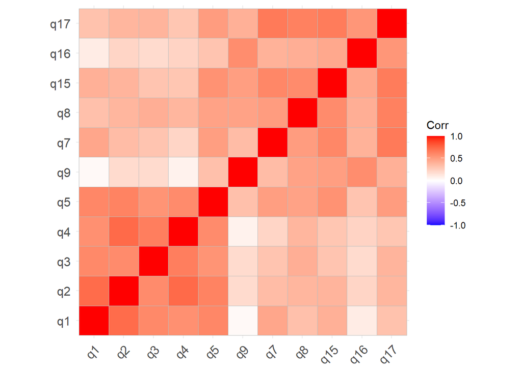

Figure 1: Basic Correlation Matrix

```r
# 1. Basic correlation matrix plot
ggcorrplot::ggcorrplot(uxMatrix)
```

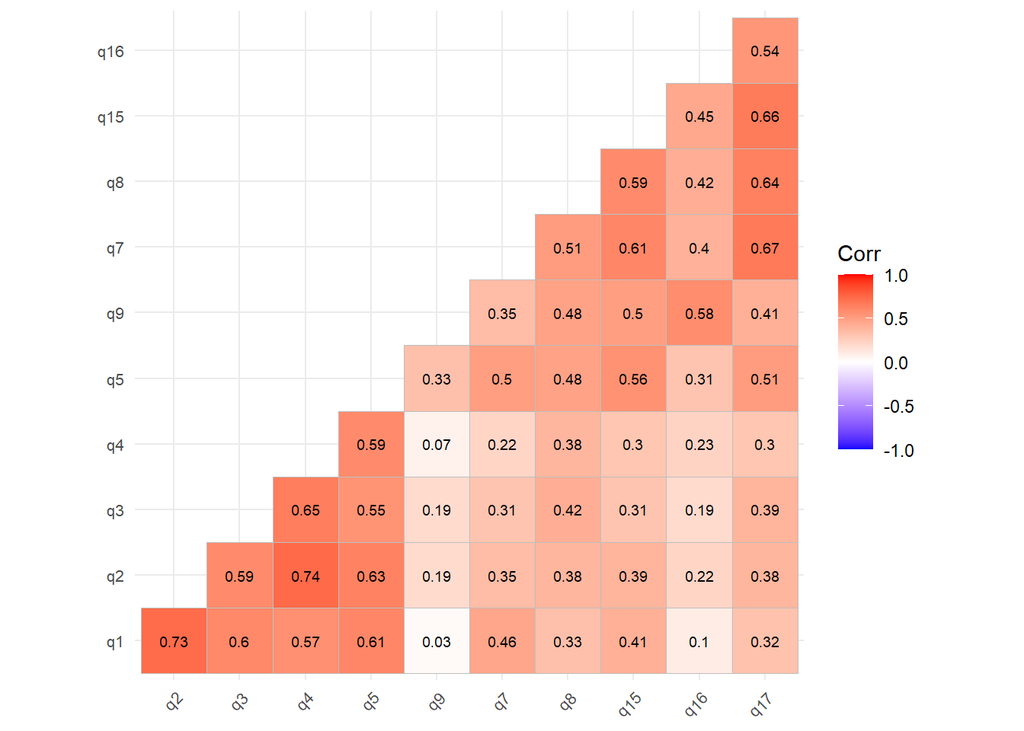

Figure 1: Correlation Matrix - uxData Dataset

```r
# 5. Correlation matrix showing coefficients with labels
# Note: This can become cluttered with a high number of variables
#| fig-width: 16
#| fig-height: 16

ggcorrplot::ggcorrplot(
  uxMatrix,
  lab = TRUE,
  lab_size = 2.5,
  tl.cex = 8,
  tl.srt = 45,
  type = "lower"
)
```

# STEP 2: Check if the data is suitable for dimension reduction (there is enough variance of the right kind)

You want to do the following:

- Check that your variables are correlated by doing Bartlett’s test of Sphericity.
  - Check that the result is statistically significant.
- Check that variables are not too highly correlated for PCA.
  - Calculate and inspect the determinant.
  - Check to see if it is greater than 0.00001.
- Check that there is enough variance in your variables that could be caused by an underlying factor/dimension.
  - Use the Kaiser-Meyer-Olkin Measure of Sampling Adequacy (MSA) test.
  - High values close to 1 suggest that PCA/FA might be useful.
  - Values over 0.8 or over are considered strong.
  - Anything less than 0.5 suggests that PCA/FA won’t be useful.
  - 0.00 to 0.49 unacceptable, 0.50 to 0.59 miserable, 0.60 to 0.69 mediocre ,0.70 to 0.79 middling, 0.80 to 0.89 meritorious, 0.90 to 1.00 marvellous.
  - [Kaiser-Meyer-Olkin (KMO) Test for Sampling Adequacy](https://www.statisticshowto.com/kaiser-meyer-olkin/)

## Step 2a: Check Bartlett’s test

```r
psych::cortest.bartlett(uxData)
```

```
R was not square, finding R from data
```

```
$chisq
[1] 455.9277

$p.value
[1] 1.637237e-64

$df
[1] 55
```

## STEP 2b: Check the (KMO)

```r
#KMO
REdaS::KMOS(uxData)
```

```
Kaiser-Meyer-Olkin Statistics

Call: REdaS::KMOS(x = uxData)

Measures of Sampling Adequacy (MSA):
       q1        q2        q3        q4        q5        q9        q7        q8
0.7547769 0.7922312 0.8435921 0.7419398 0.9328888 0.6422688 0.8760714 0.9026210
      q15       q16       q17
0.8901833 0.7772193 0.8032700

KMO-Criterion: 0.8175597
```

## STEP 2c: Check the Determinant

```r
#Determinant:
det(uxMatrix)
```

```
[1] 0.001165641
```

## STEP 2d : Suitability of the Data for Dimension Reduction

Data Observations and requirements for dimension reduction

- shape of dataframe uxData = (73, 11)
- all variables are numeric and treated as continuous.
- all variables are ‘int’ type (none coded as factor types)
- all variables have values of ‘1’ or ‘2’ as a min value, with max value of ‘10’ appearing in all variables.
- Data appears like a questionnaire with responses values in a 10-point Likert scale. This corresponds to the description on th kaggle website where the data was sourced from.
- A guideline is that ordered data should be in the same direction i.e. for ordinal positive and negative values align. If they do not we should reverse code to ensure they do. We do not know the original questions however so cannot determine any direction in the data, and as such we will not reverse code the data.
- Guidelines suggest a minimum of 5 observations per variable, with some guidelines recommending at least 100 observations. We require minimum 55 observations. While we do not meet the 100 observations guide, we exceed our minimum requirement with 73 rows in our dataframe i.e. (73 > 55).

Using the guidance of Field (2024), the questionnaire response data was assessed for its suitability for dimension reduction. Bartlett’s test of sphericity produced a significant result, χ²(55) = 455.93, p < 0.001, indicating that the observed correlation matrix is not an identity matrix and therefore contains sufficient shared variance for factor extraction. The Kaiser–Meyer–Olkin (KMO) Measure of Sampling Adequacy was ‘0.82’, which falls within the “meritorious” range according to Kaiser and Rice’s (1974) criteria, suggesting that the dataset is well suited for dimension reduction techniques. Examination of the determinant of the correlation matrix yielded a value of ‘0.00116’, which is above the recommended minimum threshold of 0.00001, further indicating that the data is not affected by multicollinearity or singularity issues. Collectively, these diagnostics demonstrate that the ‘uxData’ dataset is appropriate for principal component analysis or exploratory factor analysis

# STEP 3: Execute the PCA

In this step, run the PCA using all of the remaining variables in the uxData dataset. The purpose here is simply to let R extract all possible components so we can see the complete structure of the data. You should focus on the loading matrix that is produced. A loading tells you how strongly each variable relates to a component. At this stage you are not trying to interpret all components; instead, you are trying to understand the overall structure so that we can make decisions in the next step.

```r
#do the reduction
pc1 <-  principal(uxData, nfactors = length(uxData), rotate = "none")#Conduct the PCA extracting the same number of components as there are variables

pc1#output all details of the PCA
```

```
Principal Components Analysis
Call: principal(r = uxData, nfactors = length(uxData), rotate = "none")
Standardized loadings (pattern matrix) based upon correlation matrix
     PC1   PC2   PC3   PC4   PC5   PC6   PC7   PC8   PC9  PC10  PC11 h2      u2
q1  0.69 -0.51 -0.25  0.20 -0.04  0.15  0.21  0.10  0.15 -0.19  0.16  1 0.0e+00
q2  0.74 -0.47  0.12  0.19  0.01 -0.10  0.25 -0.02 -0.26 -0.02 -0.18  1 1.0e-15
q3  0.69 -0.41  0.19 -0.28 -0.03  0.42 -0.18  0.16  0.01  0.03 -0.08  1 1.1e-16
q4  0.67 -0.52  0.31 -0.08  0.16 -0.23 -0.03 -0.04  0.05  0.27  0.15  1 2.9e-15
q5  0.81 -0.18 -0.03  0.17 -0.17 -0.14 -0.38 -0.25  0.07 -0.16 -0.04  1 1.3e-15
q9  0.51  0.58  0.39  0.19 -0.38  0.18  0.07 -0.05 -0.12  0.07  0.11  1 5.6e-16
q7  0.71  0.27 -0.48  0.10  0.15  0.22  0.05 -0.22  0.03  0.25 -0.04  1 1.4e-15
q8  0.74  0.26  0.02 -0.48 -0.17 -0.14  0.24 -0.14  0.16 -0.08 -0.04  1 8.9e-16
q15 0.76  0.32 -0.23  0.10 -0.19 -0.23 -0.08  0.38  0.08  0.12 -0.06  1 1.2e-15
q16 0.55  0.52  0.39  0.19  0.43  0.03  0.02  0.04  0.19 -0.11 -0.06  1 2.2e-16
q17 0.77  0.35 -0.19 -0.21  0.24 -0.05 -0.10  0.06 -0.31 -0.14  0.12  1 1.2e-15
    com
q1  3.3
q2  2.7
q3  3.4
q4  3.4
q5  2.2
q9  4.4
q7  3.1
q8  2.8
q15 2.7
q16 4.4
q17 2.7

                       PC1  PC2  PC3  PC4  PC5  PC6  PC7  PC8  PC9 PC10 PC11
SS loadings           5.37 1.93 0.84 0.55 0.53 0.43 0.37 0.32 0.28 0.25 0.13
Proportion Var        0.49 0.18 0.08 0.05 0.05 0.04 0.03 0.03 0.03 0.02 0.01
Cumulative Var        0.49 0.66 0.74 0.79 0.84 0.88 0.91 0.94 0.97 0.99 1.00
Proportion Explained  0.49 0.18 0.08 0.05 0.05 0.04 0.03 0.03 0.03 0.02 0.01
Cumulative Proportion 0.49 0.66 0.74 0.79 0.84 0.88 0.91 0.94 0.97 0.99 1.00

Mean item complexity =  3.2
Test of the hypothesis that 11 components are sufficient.

The root mean square of the residuals (RMSR) is  0
 with the empirical chi square  0  with prob <  NA

Fit based upon off diagonal values = 1
```

The initial unrotated PCA was performed using all possible components, extracting 11 components — one for each original variable.

The unrotated loading matrix showed that several variables loaded strongly on the first component, including q5 (.81), q15 (.76), q8 (.74) and q2 (.74). These variables represent related aspects of the questionaire. Other components showed weaker and more diffuse patterns, reflecting the fact that PCA extracts all variance, including variance that is not meaningful.

The eigenvalues indicated that the first three components explained the majority of total variance:

PC1: 5.37 (48.8%)

PC2: 1.93 (17.6%)

PC3: 0.84 (7.6%)

Together, the first three components accounted for 74% of total variance, with subsequent components contributing very little, each eigen value being below 1and explaining approx < or less 5% of the total variance each).

Only the first two components meet the Kaiser criterion > 1, namely PC1 = 5.37 and PC2 = 1.93.

# STEP 4: Decide on which components to retain

Once the full PCA is run, you need to decide how many components to keep for interpretation. There are two main things to look at:

The scree plot – This helps you visually identify where the “elbow” or point of inflexion is. After this point, the components explain very little additional variance.

Eigenvalues – A common guideline is to keep components with eigenvalues greater than 1 (Kaiser’s criterion) or greater than 0.7 (Joliffe’s criterion).

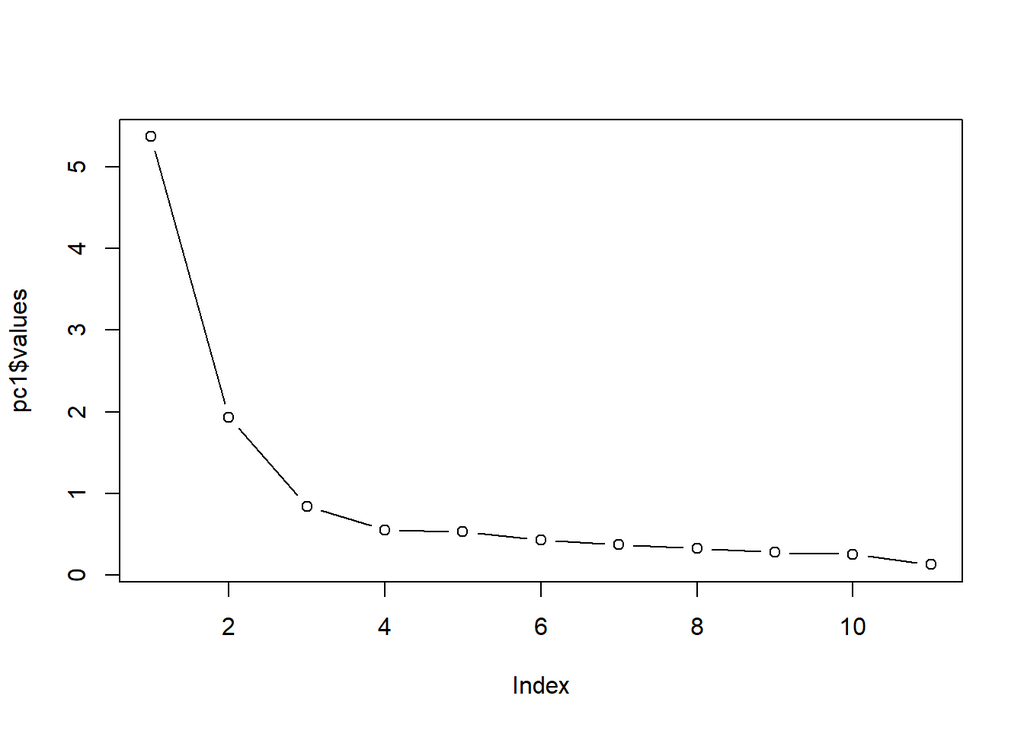

```r
#Create the scree plot
plot(pc1$values, type = "b")
```

```r
#Print the variance explained by each component
pc1$Vaccounted
```

```
                            PC1       PC2        PC3        PC4        PC5
SS loadings           5.3691920 1.9295711 0.83965924 0.55318862 0.52808318
Proportion Var        0.4881084 0.1754156 0.07633266 0.05028987 0.04800756
Cumulative Var        0.4881084 0.6635239 0.73985658 0.79014645 0.83815402
Proportion Explained  0.4881084 0.1754156 0.07633266 0.05028987 0.04800756
Cumulative Proportion 0.4881084 0.6635239 0.73985658 0.79014645 0.83815402
                             PC6        PC7        PC8        PC9       PC10
SS loadings           0.43081272 0.36922369 0.32344323 0.27600845 0.25329275
Proportion Var        0.03916479 0.03356579 0.02940393 0.02509168 0.02302661
Cumulative Var        0.87731881 0.91088460 0.94028853 0.96538021 0.98840682
Proportion Explained  0.03916479 0.03356579 0.02940393 0.02509168 0.02302661
Cumulative Proportion 0.87731881 0.91088460 0.94028853 0.96538021 0.98840682
                            PC11
SS loadings           0.12752498
Proportion Var        0.01159318
Cumulative Var        1.00000000
Proportion Explained  0.01159318
Cumulative Proportion 1.00000000
```

```r
#Print the Eigenvalues
pc1$values
```

```
 [1] 5.3691920 1.9295711 0.8396592 0.5531886 0.5280832 0.4308127 0.3692237
 [8] 0.3234432 0.2760084 0.2532927 0.1275250
```

```r
#Another way to look at the eigenvalues plus variance explained (need to use princomp function of PCA to get right class for use with factoextra functions)
pcf=princomp(uxData)
factoextra::get_eigenvalue(pcf)
```

```
       eigenvalue variance.percent cumulative.variance.percent
Dim.1  22.2044804        47.804527                    47.80453
Dim.2   8.6287260        18.576979                    66.38151
Dim.3   3.6889808         7.942090                    74.32360
Dim.4   2.4230127         5.216559                    79.54015
Dim.5   2.2842408         4.917794                    84.45795
Dim.6   1.8791881         4.045746                    88.50369
Dim.7   1.4424291         3.105438                    91.60913
Dim.8   1.2679015         2.729694                    94.33883
Dim.9   1.1053225         2.379674                    96.71850
Dim.10  0.9844934         2.119538                    98.83804
Dim.11  0.5397140         1.161963                   100.00000
```

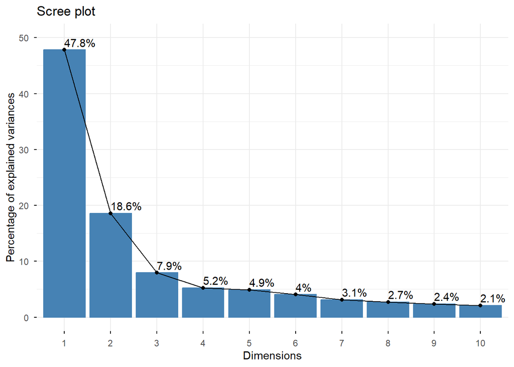

```r
factoextra::fviz_eig(pcf, addlabels = TRUE, ylim = c(0, 50))#Visualize the Eigenvalues
```

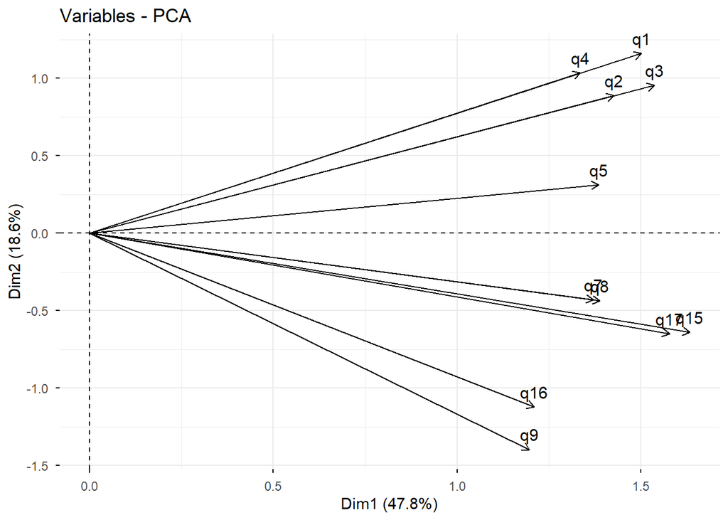

```r
factoextra::fviz_pca_var(pcf, col.var = "black")
```

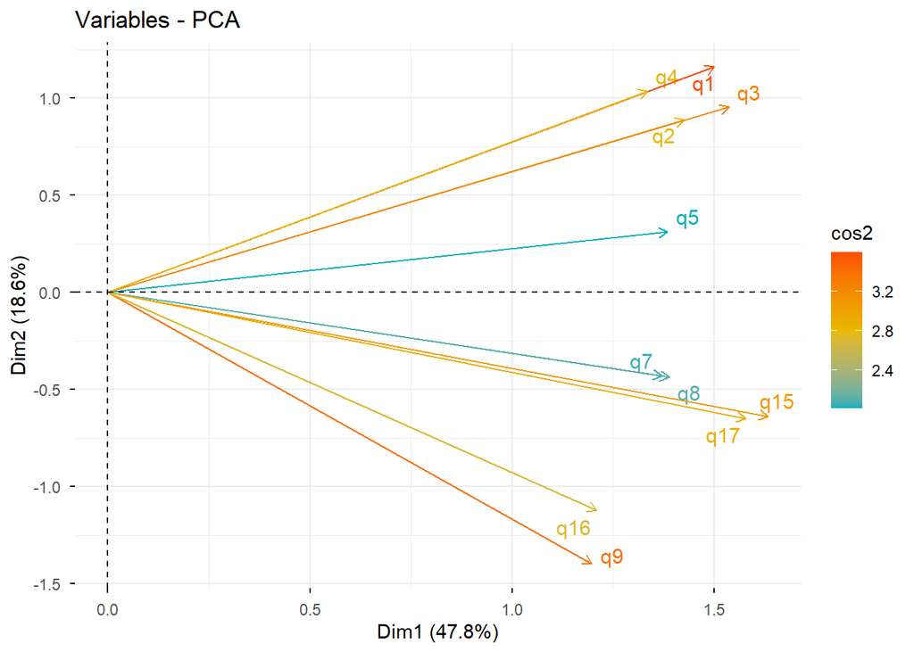

```r
factoextra::fviz_pca_var(pcf, col.var = "cos2",
             gradient.cols = c("#00AFBB", "#E7B800", "#FC4E07"),
             repel = TRUE # Avoid text overlapping
             )
```

```r
#Print the loadings above the level of 0.3
psych::print.psych(pc1, cut = 0.3, sort = TRUE)
```

```
Principal Components Analysis
Call: principal(r = uxData, nfactors = length(uxData), rotate = "none")
Standardized loadings (pattern matrix) based upon correlation matrix
    item  PC1   PC2   PC3   PC4   PC5   PC6   PC7   PC8   PC9 PC10 PC11 h2
q5     5 0.81                               -0.38                        1
q17   11 0.77  0.35                                     -0.31            1
q15    9 0.76  0.32                                0.38                  1
q2     2 0.74 -0.47                                                      1
q8     8 0.74             -0.48                                          1
q7     7 0.71       -0.48                                                1
q1     1 0.69 -0.51                                                      1
q3     3 0.69 -0.41                    0.42                              1
q4     4 0.67 -0.52  0.31                                                1
q16   10 0.55  0.52  0.39        0.43                                    1
q9     6 0.51  0.58  0.39       -0.38                                    1
         u2 com
q5  1.3e-15 2.2
q17 1.2e-15 2.7
q15 1.2e-15 2.7
q2  1.0e-15 2.7
q8  8.9e-16 2.8
q7  1.4e-15 3.1
q1  0.0e+00 3.3
q3  1.1e-16 3.4
q4  2.9e-15 3.4
q16 2.2e-16 4.4
q9  5.6e-16 4.4

                       PC1  PC2  PC3  PC4  PC5  PC6  PC7  PC8  PC9 PC10 PC11
SS loadings           5.37 1.93 0.84 0.55 0.53 0.43 0.37 0.32 0.28 0.25 0.13
Proportion Var        0.49 0.18 0.08 0.05 0.05 0.04 0.03 0.03 0.03 0.02 0.01
Cumulative Var        0.49 0.66 0.74 0.79 0.84 0.88 0.91 0.94 0.97 0.99 1.00
Proportion Explained  0.49 0.18 0.08 0.05 0.05 0.04 0.03 0.03 0.03 0.02 0.01
Cumulative Proportion 0.49 0.66 0.74 0.79 0.84 0.88 0.91 0.94 0.97 0.99 1.00

Mean item complexity =  3.2
Test of the hypothesis that 11 components are sufficient.

The root mean square of the residuals (RMSR) is  0
 with the empirical chi square  0  with prob <  NA

Fit based upon off diagonal values = 1
```

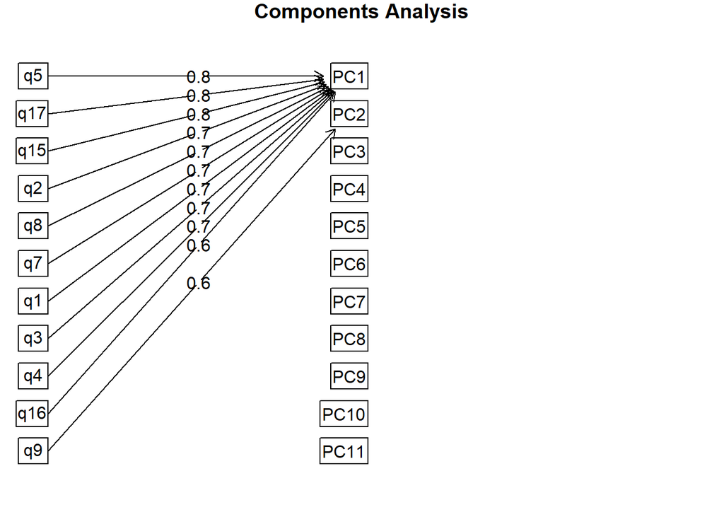

```r
#Create a diagram showing the components and how the manifest variables load
fa.diagram(pc1)
```

```r
#Show the loadings of variables on to components
fa.sort(pc1$loading)
```

```
Loadings:
    PC1    PC2    PC3    PC4    PC5    PC6    PC7    PC8    PC9    PC10
q5   0.807 -0.181         0.171 -0.169 -0.138 -0.381 -0.250        -0.156
q17  0.766  0.354 -0.194 -0.212  0.242        -0.104        -0.311 -0.138
q15  0.758  0.320 -0.227        -0.186 -0.226         0.384         0.117
q2   0.744 -0.470  0.121  0.188        -0.104  0.251        -0.263
q8   0.737  0.263        -0.476 -0.172 -0.137  0.241 -0.142  0.158
q7   0.707  0.268 -0.482  0.101  0.148  0.216        -0.221         0.252
q1   0.693 -0.507 -0.247  0.201         0.147  0.211         0.151 -0.189
q3   0.687 -0.411  0.190 -0.284         0.419 -0.183  0.157
q4   0.668 -0.523  0.310         0.157 -0.229                       0.270
q16  0.552  0.518  0.391  0.185  0.432                       0.186 -0.106
q9   0.508  0.583  0.395  0.189 -0.375  0.178               -0.119
    PC11
q5
q17  0.123
q15
q2  -0.179
q8
q7
q1   0.162
q3
q4   0.150
q16
q9   0.110

                 PC1   PC2   PC3   PC4   PC5   PC6   PC7   PC8   PC9  PC10
SS loadings    5.369 1.930 0.840 0.553 0.528 0.431 0.369 0.323 0.276 0.253
Proportion Var 0.488 0.175 0.076 0.050 0.048 0.039 0.034 0.029 0.025 0.023
Cumulative Var 0.488 0.664 0.740 0.790 0.838 0.877 0.911 0.940 0.965 0.988
                PC11
SS loadings    0.128
Proportion Var 0.012
Cumulative Var 1.000
```

Communalities - tell us how much of each variable’s variance is captured by the components we keep. A communality close to 1 means the retained components represent that variable very well. A communality below about 0.4 may indicate that the variable is not well represented.

```r
#Output the communalities of variables across components (will be one for PCA since all the variance is used)
pc1$communality
```

```
 q1  q2  q3  q4  q5  q9  q7  q8 q15 q16 q17
  1   1   1   1   1   1   1   1   1   1   1
```

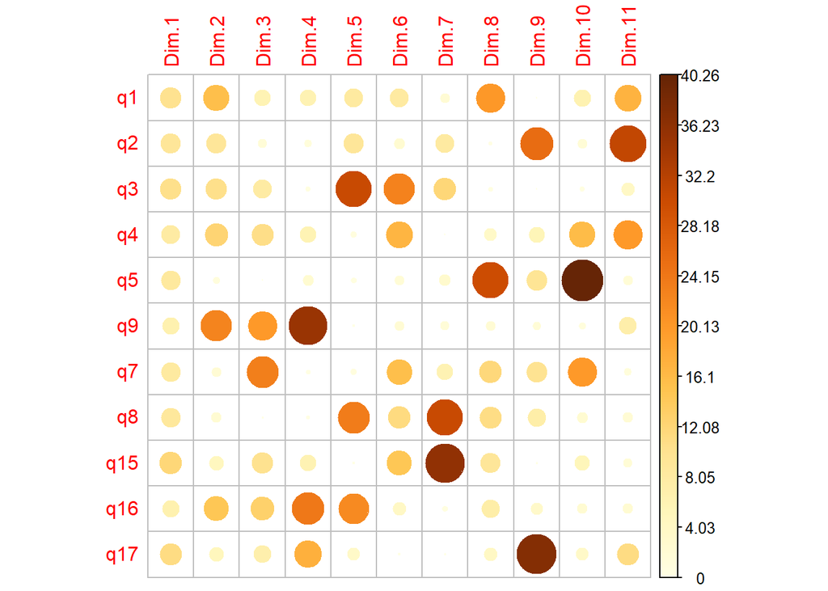

```r
#Visualize contribution of variables to each component
var <- factoextra::get_pca_var(pcf)
corrplot::corrplot(var$contrib, is.corr=FALSE)
```

***If you want to visualize the contributions of the variables to each component use this code**

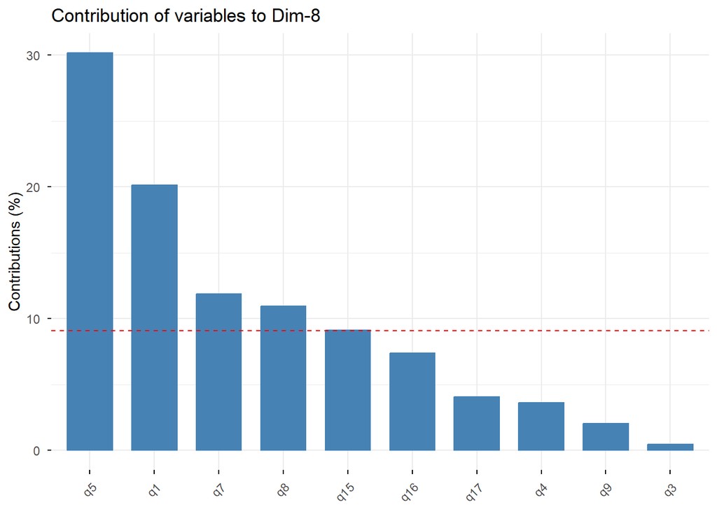

```r
# Contributions of variables to PC?
factoextra::fviz_contrib(pcf, choice = "var", axes = 8, top = 10)# Replace the value for axes with the number of the component e.g. 1 for PC1, 2 for PC2, 8 for PC8
```

## Step 4a. Decide how many components to retain and complete the code for Step 5

Two criteria were used:

1. Scree plot

The scree plot showed a clear “elbow” at Component 2, with a possible additional inflection at component ‘3’ indicating that meaningful reductions end after 2, but additional inflection at components ‘3’ although not as sharp as it is after ‘2’, from a visual inspection. Components 4–11 contributed trivial additional variance.

2. Eigenvalues

Kaiser’s criterion (eigenvalue > 1) supported retaining two components (5.37, 1.93). Joliffe’s criterion (eigenvalue > 0.7) would retain the third component (0.84).

Inspection revealed that the third component was statistically weak and conceptually incoherent, only adding 8% proportion variance to components ‘1’ and ‘2’, who together account for 66%. Also, only one loading for component ‘3’ nears 0.5, for variables that are conceptually related, namely q7 = -0.48, and little loading across other components.

Decision: A **two-component** solution was chosen as the most parsimonious and theoretically interpretable representation of the data.

# STEP 5: Repeat with reduced components and rotation

*You must:* - Decide how may components to retain - Re-run the PCA asking for only those components - Apply a rotation — usually varimax when doing PC

NOTE: I did not re-run the exploratory PCA that was run earlier, as thought it best to leave the existing value nfactors=length(uxData)’ so the thought process and analysis was visible in the rendered html and .qmd if needed. This was a conscious decision. so hopefully the correct one. I proceeded on to perform PCA with verimax rotation next.

The rotated solution gives you a clearer picture of the underlying dimensions in the dataset, and this is the version you would normally interpret.

```r
#Apply rotation to try to refine the component structure- you decide how may
pc2 <-  principal(uxData, nfactors = 2, rotate = "varimax") #replace the value of nfactors with the number of components to retain
#output the components, cuts out anythign below 0.3 and sort but strongest first
psych::print.psych(pc2, cut = 0.3, sort = TRUE)
```

```
Principal Components Analysis
Call: principal(r = uxData, nfactors = 2, rotate = "varimax")
Standardized loadings (pattern matrix) based upon correlation matrix
    item   RC1   RC2   h2   u2 com
q2     2  0.86       0.77 0.23 1.1
q1     1  0.85       0.74 0.26 1.0
q4     4  0.84       0.72 0.28 1.0
q3     3  0.78       0.64 0.36 1.1
q5     5  0.70  0.44 0.68 0.32 1.7
q17   11        0.79 0.71 0.29 1.3
q9     6        0.77 0.60 0.40 1.0
q15    9  0.31  0.76 0.68 0.32 1.3
q16   10        0.76 0.57 0.43 1.0
q8     8  0.34  0.71 0.61 0.39 1.4
q7     7  0.31  0.69 0.57 0.43 1.4

                       RC1  RC2
SS loadings           3.67 3.63
Proportion Var        0.33 0.33
Cumulative Var        0.33 0.66
Proportion Explained  0.50 0.50
Cumulative Proportion 0.50 1.00

Mean item complexity =  1.2
Test of the hypothesis that 2 components are sufficient.

The root mean square of the residuals (RMSR) is  0.07
 with the empirical chi square  42.34  with prob <  0.15

Fit based upon off diagonal values = 0.98
```

```r
#output the communalities, the contribution of variables to each component
pc2$communality
```

```
       q1        q2        q3        q4        q5        q9        q7        q8
0.7368928 0.7739081 0.6406841 0.7199565 0.6844184 0.5977330 0.5717556 0.6125703
      q15       q16       q17
0.6761506 0.5731144 0.7115793
```

```r
#NOTE: you can do all the other things done for the model in step 4 if you want to
pc2$Vaccounted
```

```
                            RC1       RC2
SS loadings           3.6704613 3.6283018
Proportion Var        0.3336783 0.3298456
Cumulative Var        0.3336783 0.6635239
Proportion Explained  0.5028881 0.4971119
Cumulative Proportion 0.5028881 1.0000000
```

## Step 5a: Report the outcomes of the PCA

A principal component analysis (PCA) with varimax rotation was conducted on the ‘uxData’ dataset to explore the underlying structure of its UX variables. An initial unrotated PCA indicated that the first two components had eigenvalues exceeding Kaiser’s criterion and together explained 66% of the total variance. The scree plot showed a clear point of inflection after the second component, supporting the retention of two components as the most interpretable and parsimonious solution.

The rotated PCA revealed a clear and coherent structure:

Component 1: Navigation This component showed strong positive loadings from q2 (.86), q1 (.85), q4 (.84), q3 (.78) and q5(.70), These variables represent ease of site navigation. High communalities (e.g., q2 h² = .77; q1 h² = .74) indicate that this component captures a substantial proportion of variance in these variables.

Component 2: Typography, Colour and Interactivity This component showed strong positive loadings from q17 (.79), q9 (.77), q15 (.76), q16 (.76) and q8(.71). These variables are closely linked to site typography, Colour and Interactivity. Communalities for these indicators were moderate to high ((e.g., q17 h² = .71; q9 h² = .60)), supporting the component’s coherence.

The two retained components reflect key dimensions of user experience such as navigation, typography, colour and interctivity.

# Step 6a. Complete the Code for Reliability Analysis

# STEP 6: Reliability Analysis

Check whether the variables within each proposed group consistently measure the same underlying construct.

Cronbach’s alpha is used to evaluate internal consistency: α > .80 = good α ~ .70 = acceptable α < .60 = poor

Note: Dimension reduction does NOT guarantee reliability. A component/factor may be statistically valid but not reliable as a scale. If we are just trying to reduce the number of variables we may still be able to use. If however we want to use the component/factor as a reliable measure of a concept it will cause use problems if it is not considered reliable.

```r
#If you know that certain sections should be treated as groups, test these separately
#Output Cronbach alpha values - use pysch::alpha

# Component 1: navigation
comp1_vars <- uxData[, c("q2", "q4", "q1", "q3", "q5")]

# Component 2:  typography, colour and interctivity.
comp2_vars <- uxData[, c("q17", "q9", "q15", 'q16', 'q8' )]

# Compute Cronbach's Alpha for each PCA-derived component
psych::alpha(comp1_vars)   # navigation
```

```
Reliability analysis
Call: psych::alpha(x = comp1_vars)

  raw_alpha std.alpha G6(smc) average_r S/N  ase mean  sd median_r
      0.89      0.89    0.88      0.63 8.4 0.02  7.7 1.7      0.6

    95% confidence boundaries
         lower alpha upper
Feldt     0.85  0.89  0.93
Duhachek  0.85  0.89  0.93

 Reliability if an item is dropped:
   raw_alpha std.alpha G6(smc) average_r S/N alpha se  var.r med.r
q2      0.85      0.85    0.82      0.59 5.9    0.028 0.0011  0.60
q4      0.86      0.87    0.84      0.62 6.5    0.026 0.0037  0.60
q1      0.87      0.87    0.84      0.63 6.7    0.025 0.0042  0.61
q3      0.88      0.88    0.86      0.64 7.3    0.023 0.0054  0.62
q5      0.88      0.88    0.86      0.65 7.3    0.024 0.0055  0.62

 Item statistics
    n raw.r std.r r.cor r.drop mean  sd
q2 73  0.88  0.88  0.86   0.81  7.9 2.0
q4 73  0.85  0.85  0.81   0.75  7.4 2.0
q1 73  0.84  0.84  0.79   0.74  8.0 2.2
q3 73  0.82  0.81  0.74   0.70  7.8 2.2
q5 73  0.79  0.81  0.73   0.69  7.5 1.8

Non missing response frequency for each item
      1    2    3    4    5    6    7    8    9   10 miss
q2 0.01 0.01 0.01 0.03 0.04 0.08 0.12 0.25 0.25 0.19    0
q4 0.00 0.01 0.04 0.05 0.04 0.18 0.14 0.15 0.23 0.15    0
q1 0.04 0.00 0.01 0.03 0.03 0.07 0.10 0.21 0.25 0.27    0
q3 0.01 0.03 0.01 0.04 0.07 0.08 0.08 0.15 0.27 0.25    0
q5 0.00 0.03 0.00 0.01 0.08 0.12 0.19 0.29 0.14 0.14    0
```

```r
psych::alpha(comp2_vars)   # typography, colour and interctivity.
```

```
Reliability analysis
Call: psych::alpha(x = comp2_vars)

  raw_alpha std.alpha G6(smc) average_r S/N   ase mean  sd median_r
      0.85      0.85    0.84      0.53 5.6 0.029  7.5 1.7     0.52

    95% confidence boundaries
         lower alpha upper
Feldt     0.78  0.85   0.9
Duhachek  0.79  0.85   0.9

 Reliability if an item is dropped:
    raw_alpha std.alpha G6(smc) average_r S/N alpha se  var.r med.r
q17      0.80      0.80    0.76      0.50 4.0    0.038 0.0047  0.49
q9       0.83      0.83    0.80      0.55 4.9    0.033 0.0101  0.57
q15      0.81      0.81    0.79      0.51 4.2    0.037 0.0085  0.51
q16      0.82      0.83    0.80      0.55 4.8    0.034 0.0101  0.54
q8       0.81      0.81    0.79      0.52 4.4    0.036 0.0085  0.52

 Item statistics
     n raw.r std.r r.cor r.drop mean  sd
q17 73  0.82  0.83  0.79   0.71  8.1 2.1
q9  73  0.76  0.75  0.67   0.60  7.1 2.3
q15 73  0.81  0.81  0.75   0.68  7.6 2.2
q16 73  0.76  0.76  0.68   0.62  7.0 2.1
q8  73  0.78  0.79  0.73   0.66  7.6 1.9

Non missing response frequency for each item
       1    2    3    4    5    6    7    8    9   10 miss
q17 0.03 0.01 0.01 0.00 0.04 0.04 0.16 0.21 0.21 0.29    0
q9  0.01 0.03 0.07 0.03 0.10 0.08 0.23 0.14 0.16 0.15    0
q15 0.03 0.03 0.00 0.01 0.10 0.07 0.12 0.32 0.12 0.21    0
q16 0.03 0.01 0.01 0.04 0.12 0.18 0.15 0.14 0.21 0.11    0
q8  0.00 0.03 0.03 0.00 0.08 0.08 0.19 0.23 0.21 0.15    0
```

```r
# https://www.rdocumentation.org/packages/psych/versions/2.5.6/topics/alpha - alpha based on covariances
cat(sprintf(" \nComponent 1 raw alpha = %.3f\n" , psych::alpha(comp1_vars)$total$raw_alpha))
```

```
Component 1 raw alpha = 0.891
```

```r
cat(sprintf(" \nComponent 2 raw alpha = %.3f\n" , psych::alpha(comp2_vars)$total$raw_alpha))
```

```
Component 2 raw alpha = 0.846
```

```r
# cat(sprintf(" component 1 raw alpha = " , psych::alpha(comp1_vars)$total$raw_alpha))

#If you know that certain sections should be treated as groups, test these separately
#Output Cronbach alpha values - use pysch::alpha

# Compute Cronbach's Alpha for the entire dataset
# psych::alpha(uxData)
#Note: You should break this out into components.
```

## Step 6a. - Report the outcomes of the Reliability Analysis

Internal consistency was evaluated for each of the two PCA-derived components using Cronbach’s alpha. Reliability was assessed to determine whether the variables loading on each component form a coherent measurement scale rather than merely a statistical grouping. This distinction is important because PCA identifies patterns of shared variance but does not guarantee that the resulting components represent reliable constructs.

Component 1: Component 1 included items ‘q1’, ‘q2’, ‘q3’, ‘q4’ and ‘q5’ which related to navigation. Cronbach’s alpha for this set of variables was: α = .891. This indicates acceptable internal consistency. Inspection of the item-deleted statistics showed that all items correlated strongly with the underlying component.

Component 2 included items ‘q17’, ‘q9’, ‘q15’, ‘q16’ and ‘q8’ which related to typography, colour and interctivity. Cronbach’s alpha for this set of variables was: α = .846. This indicates acceptable internal consistency, and that the variables function together as a coherent measurement scale.

In summary, both Component 1 and component 2 show good internal coherence and could be used as a reliable composite scale.

## Syep 7. Summary Conclusion on the PCA

In this project we conducted Principal Component Analysis (PCA) on our ‘uxData’ dataset to dimension reduction to dertmine if ti could be reliably and meanginfully be achieved. The data set had ‘11’ variables and ‘73’ rows of data, and consisted of a set of website user experience questionairre responses. We performed the following tasks.

Firstly, we determined if the variables were suitable candidates for reduction and if they met the requirements for PCA. It confirmed that sufficient correlation existed across the variables without it leading to multicollinearity. Bartletts test was performed on the data and it proved to be statistically significant aswell as the Kaiser-Meyer-Olkin (KMO) test being performed which fell within the ‘meritorious’ range according to Kaiser and Rice’s (1974) criteria. The determinant value of ‘0.00116’ was also obtained, all of which collectively, along with some manual and visual inspection determined the suitability of the variables for PCA.

An initial unrotated PCA indicated that the first two components accounted fr a substantial proportion of total variance, and inspection of the eigenvalues and the scree plot helped determine taking a two component approach. We could have added and additional third component using Joliffe’s criteria, but under the approach of variable parsimony this addition adding limited explanatory value it would have added, along with the weak and diffuse nature of the variable, it as decided not to include it and persist with a two component approach.

A verimax (orthogonal) rotated PCA produced a clear, distinct two component structure. The first component being related to navigation and the second being related to typography, colour and interactivity. The aim of the rotation was to clarify the data structure, reallocating the variable variance across the factors, with both then contributing approcx 33% of variable for a total of 66%.

Overall, the dataset under went dimension reduction from 11 variables to two components successfully, using PCA, retaining meaning and reliability, allowing for them to be used in any future analysis. The reduction from 11 variables tp 2 makes the dataset more manageable for staff to use and determine areas of focus for future development, maintenance etc.